# Multivariate analysis - 2023-02-02 Linear Regresion, Sessión 3_Aft

- Instituut Voor Tropische Geneeskunde - Antwerp, Belgium
- Javier Silva-Valencia

## Step by Step

##### Import data

Importing a CSV database under the name of “usamod”, with “,” as separator and “.” as decimal:

```r
usamod <- read.csv("C:/Users/pined/OneDrive - Universidad Nacional Mayor de San Marcos/Javier 2022/Belgica/AC2/Linear Regresion Exercise Database/Datasets/usamod.csv", sep=",", dec= ".")
```

### Starting the Exercise:

The data represents a sample of 28 women. Those with ID 1 to 11 come from Pizzana, while those with ID 12 to 28 come from Steakosin

##### 1. Perform the regresion analysis on the association between cholesterol and age. Write down the equation of the model. What can you say this model.

Independant variable: Age (numeric) Dependant variable: Cholesterol (numeric)

```r
#Code in R:
lmCholes_Age = lm(cholest ~ age, data = usamod)
summary(lmCholes_Age)
```

```
Call:
lm(formula = cholest ~ age, data = usamod)

Residuals:
    Min      1Q  Median      3Q     Max
-95.934 -13.378   0.277  24.525  67.230

Coefficients:
            Estimate Std. Error t value Pr(>|t|)
(Intercept) 119.5947    21.8781   5.466 9.86e-06 ***
age           1.8612     0.4322   4.307 0.000209 ***
---
Signif. codes:  0 '***' 0.001 '**' 0.01 '*' 0.05 '.' 0.1 ' ' 1

Residual standard error: 36.55 on 26 degrees of freedom
Multiple R-squared:  0.4164,    Adjusted R-squared:  0.3939
F-statistic: 18.55 on 1 and 26 DF,  p-value: 0.0002092
```

**Note**

-A. As a result: we can recreate the formula with the data we obtained

```
* y = a+b(x)
* a= 119.5947
* b = 1.8612
    "For every increase of 1 in age, the cholesterol would increase in 1.86"
So, the formula would be:
* Y= 119.5947 +1.8612(X)
```

-B. We also find the R2

```
* R2 is the "Determination coefficient".
* R2 =  0.4164
Interpretation:
"41% of the variability of the Cholesterol could be explained by the model"
```

-C. We also find the p value = 0.0002092

```
Interpretation:
*P value in this case says that there is a statisticas association between Cholesterol
and age (that is the same that says that "the slope of the regresion line
is significanly different from zero)
```

-D. As another result we have the “correlation coefficient”

```
      Correlation coefficient = Square root of R2
So:
      Correlation coefficient (r) = sqrt(0.4164)
      Correlation coefficient (r) = 0.6452906
Interpretation:
    "The value of 0.64 suggest a strong positive association"
```

##### 2.Now generate a new variable called State (according tho the statement at the beggining). Add State to the model and write down the equation for each categorie. Does the addition of State improve the model significantly? Is this a parallell lines model or a separate lines model?

2.1 Creating the variable

```r
#Creating the variable
    usamod$state <-  "steakosin"                    #Creating a variable w/only "steakosin"
    usamod$state[usamod$id<12] <- "pizzana"         #Replacing where id<12
#When used the pizzana would be the reference (alphabetical order)
```

2.2 Puting inside the model

```r
#Code in R:
lmCholes_Age_Stat = lm(cholest ~ age + state, data = usamod)
summary(lmCholes_Age_Stat)
```

```
Call:
lm(formula = cholest ~ age + state, data = usamod)

Residuals:
    Min      1Q  Median      3Q     Max
-77.254 -17.669  -0.846  15.964  77.837

Coefficients:
               Estimate Std. Error t value Pr(>|t|)
(Intercept)     87.9993    24.7809   3.551  0.00155 **
age              2.1303     0.4199   5.074 3.08e-05 ***
statesteakosin  30.7509    13.7423   2.238  0.03439 *
---
Signif. codes:  0 '***' 0.001 '**' 0.01 '*' 0.05 '.' 0.1 ' ' 1

Residual standard error: 34.03 on 25 degrees of freedom
Multiple R-squared:  0.5138,    Adjusted R-squared:  0.4749
F-statistic: 13.21 on 2 and 25 DF,  p-value: 0.0001218
```

**Note**

- The equations for each categorie are:

  ```
  When State is Pizzana (0):
      y = 87.9993 + 2.1303(Age) + 30.7509(0)
  When State is Steakonsin (1):
      y = 87.9993  + 2.1303(Age) + 30.7509(1)
      y = 118.7502 + 2.1303(Age)
  ```

- The “Determination coefficient” is:
  - R2 = 0.5138 “51% of the variability of the Cholesterol could be explained by the model” (It is better that the previous model, but this improve is significant?)

2.3 Seeing if it improves significantly

```r
#Code for ANOVA
    anova (lmCholes_Age,lmCholes_Age_Stat)
```

```
Analysis of Variance Table

Model 1: cholest ~ age
Model 2: cholest ~ age + state
  Res.Df   RSS Df Sum of Sq      F  Pr(>F)
1     26 34742
2     25 28945  1    5797.3 5.0073 0.03439 *
---
Signif. codes:  0 '***' 0.001 '**' 0.01 '*' 0.05 '.' 0.1 ' ' 1
```

**Note**

The p value is 0.03 (less than 0.05) so the difference it is significant So, this new model (lmCholes_Age_Stat) is better. This is a parallel lines model

But So far has prove that that in the model should be included Age and also State. But: Should the model stay like this putting state as an another variable (parallel lines) or should be put state as an interaction variable (separate lines)?

##### 3.As the next step please fit a separate lines model by using interaction. Please write down the equations for pizzana and steakconsin. Is this model significantly better than the parallel lines model?

3.1 Creating the model with interaction

```r
#Code in R:
lmCholes_Age_Stat_INTERAC = lm(cholest ~ age*state, data = usamod)
summary(lmCholes_Age_Stat_INTERAC)
```

```
Call:
lm(formula = cholest ~ age * state, data = usamod)

Residuals:
    Min      1Q  Median      3Q     Max
-67.655 -19.951  -6.884  24.689  59.409

Coefficients:
                   Estimate Std. Error t value Pr(>|t|)
(Intercept)         -2.0506    40.2844  -0.051  0.95982
age                  3.8064     0.7300   5.214 2.42e-05 ***
statesteakosin     147.6374    45.3424   3.256  0.00335 **
age:statesteakosin  -2.2811     0.8517  -2.678  0.01314 *
---
Signif. codes:  0 '***' 0.001 '**' 0.01 '*' 0.05 '.' 0.1 ' ' 1

Residual standard error: 30.47 on 24 degrees of freedom
Multiple R-squared:  0.6257,    Adjusted R-squared:  0.5789
F-statistic: 13.37 on 3 and 24 DF,  p-value: 2.468e-05
```

**Note**

- The new equations for each categorie are:

  ```
  When State is Pizzana (0):
      y = -2.0506 + 3.8064(Age) + 0 + 0
  When State is Steakonsin (1):
      y = -2.0506  + 3.8064(Age) + 147.6374(1) + -2.2811(Age)(1)
      y = 145.5868 + 1.5253(Age)
  ```

- The new “Determination coefficient” is:
  - R2 = 0.6257 “62% of the variability of the Cholesterol could be explained by the model” (It is better that the previous model, but this improve is significant?)

3.2 Seeing if it improves significantly

```r
#Code for ANOVA
    anova (lmCholes_Age_Stat,lmCholes_Age_Stat_INTERAC)
```

```
Analysis of Variance Table

Model 1: cholest ~ age + state
Model 2: cholest ~ age * state
  Res.Df   RSS Df Sum of Sq      F  Pr(>F)
1     25 28945
2     24 22284  1    6660.9 7.1738 0.01314 *
---
Signif. codes:  0 '***' 0.001 '**' 0.01 '*' 0.05 '.' 0.1 ' ' 1
```

**Note**

The p value is 0.01314 (less than 0.05) so the difference it is significant So, this new model (lmCholes_Age_Stat_INTERAC) is better.

This also means that the State acts as an interaction variable, and that the regression should be presented only between 1.cholesterol and 2.age but presented separately by each group of State

(In the case of not having been significant, it would have meant that the “State” doesnt acts as an interaction variable, and that the regression should be presented between 1.cholesterol, 2.age and 3.state)

##### 4. Make an scatterplot with “Age” as X-variable, “cholesterol” as Y-variable and a regressión line for each category of “state”. At what age do the two regressions line cross? Can you calculate the age at which the lines cross from the equation in question 3?

4.1 Creating the scatterplot and linear regression only for cholest ~ age

```r
#We will try it with ggplot
library(tidyverse)                          #Install the package
```

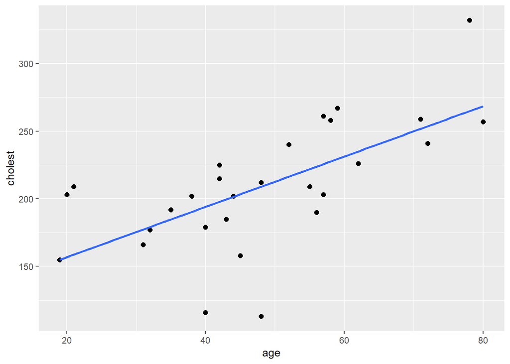

```r
#creating the graph for a linear regression of "lm(cholest ~ age, data = usamod)"
ggplot(usamod, aes(x=age, y=cholest)) +
  geom_point(size=2) +
  geom_smooth(method=lm, se=FALSE)
```

4.2 Creating the scatterplot and linear regression for cholest ~ age for each category of state

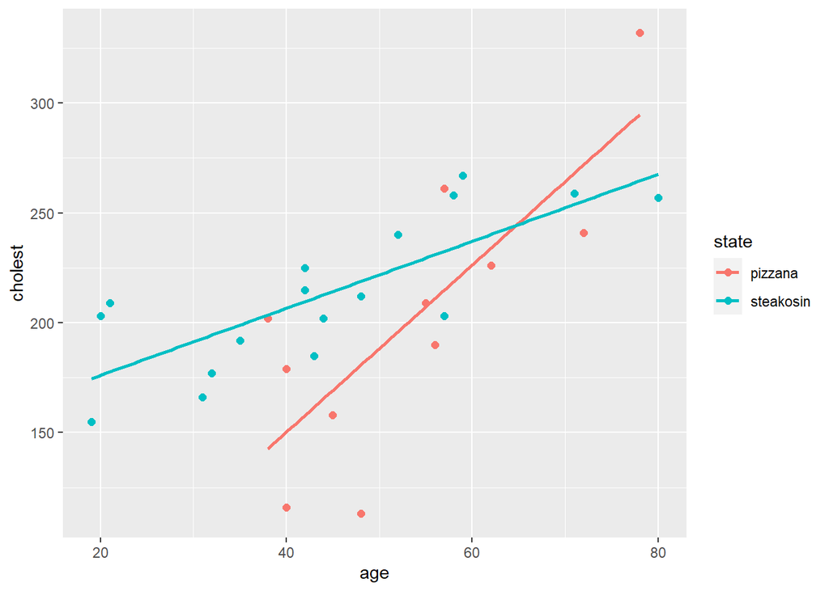

```r
#creating the graph for a linear regression of "lm(cholest ~ age*state, data = usamod)"
ggplot(usamod, aes(x=age, y=cholest, color = state)) +
  geom_point(size=2) +
  geom_smooth(method=lm, se=FALSE)
```

```
  When State is Pizzana (0):
      y = -2.0506 + 3.8064(Age) + 0 + 0
  When State is Steakonsin (1):
      y = -2.0506  + 3.8064(Age) + 147.6374(1) + -2.2811(Age)(1)
      y = 145.5868 + 1.5253(Age)

  So if there is a point that both equations have the same "Cholesterol" value, we can calculate the Age:

      -2.0506 + 3.8064(Age) = 145.5868 + 1.5253(Age)
               2.2811 (Age) = 147.6374
                      (Age) = 64.72202
```